# Activity: Street or Road?

Madeline Mucciolo

## Load in the data

```r
#load libraries
library(tidyverse)

#load in the data here
# we will only be using the "street-addresses.csv" file from the text
Addresses <- read_csv("https://mdbeckman.github.io/dcSupplement/data/street-addresses.csv")
```

## Inspect Data

```r
head(Addresses)
```

| address |
| --- |
| 2117 MARINER CIRCLE |
| 101 EPPING WAY |
| PO BOX 58592 |
| 5102 ECHO RIDGE RD |
| PO BOX 37218 |
| PO BOX 37218 |

```r
sample_n(Addresses, 10)
```

| address |
| --- |
| NCSU BOX 33290 |
| 2020 JADEWOOD DR |
| PO BOX 2162 |
| PO BOX 1482 |
| NCSU BOX 21495 |
| PO BOX 826 |
| CMR 420 BOX 439 |
| NCSU BOX 15117 |
| PO BOX 18184 |
| PO BOX 40531 |

## Recreate Solved Example using `sample(50)`

```r
Sample <-
  Addresses %>%
  sample_n(size = 50)
```

- First, gather a sample subset of 50 random cases.

```r
Matches <-
  Sample %>%
  filter(grepl(pattern = "PO", address))

Dont <-
  Sample %>%
  filter( !grepl(pattern = "PO", address))
```

- Attempt to filter out all of the cases containing “PO” (indicating they contain a PO BOX in their address). Contain these cases within two data frames, a *Matches* df for addresses with “PO” and a *Dont* df for those that do not.

```r
head(Matches)
```

| address |
| --- |
| PO BOX 396 |
| PO BOX 1006 |
| PO BOX 22 |
| PO BOX 587 |
| PO BOX 442 |
| PO BOX 536 |

```r
head(Dont)
```

| address |
| --- |
| NCSU BOX 04741 |
| NCSU BOX 21558 |
| 128 E HARGETT ST STE 10 |
| NCSU BOX 21184 |
| P O BOX 20354 |
| 202 APPLECROSS DR |

- In the *Matches* df, most of the cases look like they belong their (based on the head of the df), but after a quick glance at the *Dont* df, it is obvious there are errors. One of the addresses contains “P O” instead of “PO” so it was mistakenly included in the *Dont* df. On top of that, some cases have “NCSU” instead of “PO”, so we need to readjust our statement to correctly capture all of the cases into their appropriate data frames.

```r
pattern <- "BOX\\s+(\\d+)"

Matches <-
  Sample %>%
  filter(grepl(pattern, address))

Dont <-
  Sample %>%
  filter( !grepl(pattern, address))
```

- The improved pattern calls for “BOX” followed by numbers.

```r
head(Matches)
```

| address |
| --- |
| NCSU BOX 04741 |
| NCSU BOX 21558 |
| NCSU BOX 21184 |
| P O BOX 20354 |
| PO BOX 396 |
| PO BOX 1006 |

```r
head(Dont)
```

| address |
| --- |
| 128 E HARGETT ST STE 10 |
| 202 APPLECROSS DR |
| 68 BENNYS LN |
| 525 BRENT RD |
| 1308 BROOKS AVE |
| 5944 FAYETTEVILLE RD |

- Now the *Addresses* data frame has been much more accurately split into groupings.

## Recreate Solved Example using the entire `Address` data set

```r
address_box <-
  Addresses %>%
  filter(grepl(pattern, address))

address_no_box <-
  Addresses %>%
  filter(!grepl(pattern, address))
```

- Using the same **filter()** function on the entire *Addresses* dataset.

```r
sample_n(address_box, 10)
```

| address |
| --- |
| PO BOX 358 |
| PO BOX 1531 |
| PO BOX 41163 |
| NCSU BOX 21672 |
| PO BOX 432 |
| NCSU BOX 15768 |
| P O BOX 646 |
| BOX 22751 NCSU |
| PO BOX 90582 |
| PO BOX 1114 |

```r
sample_n(address_no_box, 10)
```

| address |
| --- |
| 4015 OLD PAGELAND-MONROE RD |
| 1202 KIRKWALL PL |
| 1464-253 GARNER STATION BLVD |
| 5017 DEVONWOOD CT |
| 142 ALLENDALE DR |
| 350 JACKSON SPRINGS RD |
| 259 ROLLING HILLS DRIVE |
| 2917 RUE SANS FAMILLE |
| MSC 0835 |
| 8251 IMPERIAL DR |

- Based on the random sample from each of these new subset data frames, both appear to be properly sorted.

```r
BoxNumbers <-
  Addresses %>%
  filter(grepl(pattern, address)) %>%
  tidyr::extract(address, into = "boxnum", regex = pattern)

sample_n(BoxNumbers,10)
```

| boxnum |
| --- |
| 28648 |
| 351 |
| 98551 |
| 163 |
| 40415 |
| 1155 |
| 1040 |
| 19511 |
| 37131 |
| 1301 |

- Now we are able to extract and view all of the individual cases box numbers.

#### Additional Question: How many addresses are a PO BOX (including NCSU BOX)?

```r
nrow(BoxNumbers)
```

```
[1] 11100
```

- By using **nrow()** on the *BoxNumbers* data frame, we can find thta there are 11,100 box number addresses in the original *Addresses* df.

## Back to the Streets: Your Turn

#### Part 1: Explain (in english) each line of the following code chunk

```r
pattern <- "(ST|RD|ROAD)"
LeftOvers <-
  Addresses %>%
  filter( !grepl(pattern, address),
          !grepl("\\sAPT|UNIT\\s[\\d]+$", address),
          !grepl(" BOX ", address)
          )
```

- The first line identifies the pattern we want to find in the data. In this case, the pattern is the detection of one of three strings: “ST”, “RD”, or “ROAD”.
- The second line is creating the name for a new variable which the following lines of code will determine its value(s).
- The third line of code takes in the *Addresses* data to be wrangled.
- The fourth line begins a **filter()** statement on the *Addresses* df. The first statement within that function is a call to **grepl()** looking to identify any *address* that DOES NOT contain the pattern identified in line one.
- The next line is a continuation of the **filter()** function and contains another **grepl()** statement, which is looking for an *address* containing “APT” or “UNITS” with spaces before/after either one and numbers afterwards.
- The final **grepl()** statement is searching for any *address* containing ” BOX “.
- Together this **grepl()** statements work together to find a new subset of addresses (Addresses that are not apartments, units, or boxes and addresses that have nto already been identified by the pattern) and store them in the newly created variable *LeftOvers*. With this new df, it is easy to look at what other endings addresses have and add them to the pattern if desired.

#### Part 2: Implement your method on the entire `Addresses` data set. Explain how your code works line by line.

```r
pattern <- "(ST|RD|ROAD|STREET|CIRCLE|DR|AVE|LANE|ROAD|DRIVE|BLVD|CT|LN|COURT|WAY)"

LeftOvers <-
  Addresses %>%
  filter( !grepl(pattern, address),
          !grepl("\\sAPT|UNIT\\s[\\d]+$", address),
          !grepl(" BOX ", address)
          )

sample_n(LeftOvers,10)
```

| address |
| --- |
| 14460 NEW FALLS OF NEUSE |
| BOX 4465 NCSU |
| 2742 RUE SANS FAMILLE |
| 1005 GREENWOOD CIR |
| 4036 RIDGEBROOK BLUFFS |
| 5214 TANNERON |
| BOX 634 |
| 103 LANIGAN PL |
| 619 BELLE RIEVE |
| BOX 2123 |

- After reiterating through and revising my pattern, I have found what seem to be the most popularly used endings for addresses.
- The first line identifies the pattern, which in this case is just a series of different common endings for addresses/street names using **or**.
- All of the other lines do exactly as they did above, but this time use my pattern instead of the pattern from the book.

```r
pop_endings <-
  Addresses %>%
  filter(grepl(pattern, address))

sample_n(pop_endings,10)
```

| address |
| --- |
| 3512 MCPHERSON ST |
| 2941 LONDON BELL DR |
| 1440 NINE IRON WAY |
| 825 VERMONT ST |
| 15 E PEACE ST APT 373 |
| 2865 BENNINGTON DR |
| 1231-F TRILLIUM CIRCLE |
| 245 BAINES CT |
| 7701 ARGYLE AVENUE |
| 6519 NEW SHARON CHURCH RD |

- I will sort addresses with popular endings into a new df called *pop_endings*.
- The first line of code creates a new variable name *pop_endings* which will store my new df.
- The second line takes the *Addresses* df and gets it ready for wrangling.
- The third line uses **filter()** and **grepl()** to extract any addresses with my pattern into my new df.

#### Additional Question 1: Present your result from part 2 by providing a table in descending order of popularity for the street name endings you found

```r
endings <-
  pop_endings %>%
  tidyr::extract(address, into = "end", regex = pattern)
```

- This code extracts all of the popular endings into their own df called *endings*, this way, we can count and sort them by popularity much easier.

```r
endings %>%
  group_by(end) %>%
  summarise(total=n()) %>%
  arrange(desc(total))
```

| end | total |
| --- | --- |
| ST | 906 |
| DR | 781 |
| RD | 756 |
| AVE | 271 |
| CT | 216 |
| ROAD | 188 |
| LN | 155 |
| WAY | 141 |
| LANE | 130 |
| COURT | 78 |

[output cut: 2 more lines]

- After grouping the data by their street endings, counting up the totals and sorting in descending order, it is easy to see that “ST” is the most commonly used in this dataset, with over 906 cases. The Second and third highest were “DR” at 781 and “RD” at 756.

#### Additional Question 2: Present your result by using ggplot to a bar chart in descending order of popularity for the street name endings you found previously.

Note: make sure your order street names according to popularity, not alphabetically.

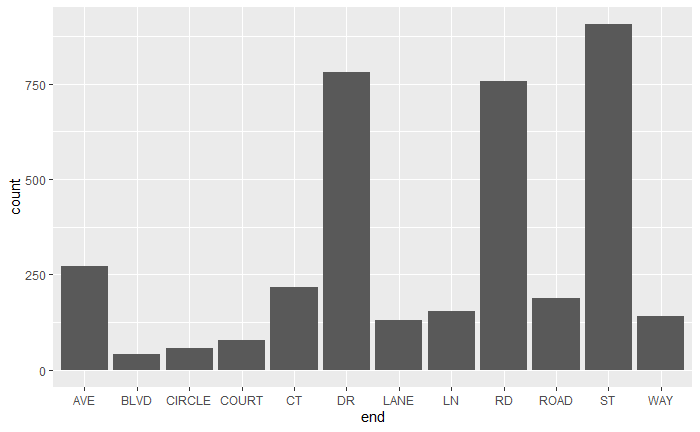

```r
endings %>%
  ggplot() + geom_bar(aes(x=end))
```

#### Additional Question 3: Comment on any patterns you see

- Overall, it seems the abbreviated names (“RD” vs “ROAD”) tend to be more commonly used.